# Homework 2. Classification and Clustering

## Classification

- Split the data randomly to training data and test data ( 70%/30% )
- What is the accuracy of (1) Logistic Regression (2) k-Nearest Neighbors (3) Naive Bayes (4) Random Forest (5) SVM model in test data
- Draw the ROC curve in Logistic Regression
- Calculate the precision and recall in k-Nearest Neighbors
- Draw the Confusion Matrix of Naive Bayes
- What is the performance with different parameters in SVM

## Clustering

- According to Gender, Education, and Marital status, how many kinds of customer should be divided into?  
  ( Hint: use the elbow method with K-means)
- Feel free and try more ^_^

## 0X00001 Preprocessing

1. First of all, we use **pandas.read_excel** to import excel documents
2. Then, we drop the 1st row because it can not be in our matrix.
3. Convert DataFrame to numpy.array
4. Use **train_test_split** to split the data randomly to training data and test data(70%/30%)
5. Split the data to **trainX**, **trainY** & **testX**, **testY**

```python
# Import libraries
import matplotlib.pyplot as plt
import pandas as pd
import numpy as np
import sys
import matplotlib
from sklearn.model_selection import train_test_split

%matplotlib inline
```

```python
# Location of file
Location = r'.\hw2.xls'
df = pd.read_excel(Location, 0)
df = df.drop(['ID'], 0)

df.head()
```

|  | X1 | X2 | X3 | X4 | X5 | X6 | X7 | X8 | X9 | X10 | ... | X15 | X16 | X17 | X18 | X19 | X20 | X21 | X22 | X23 | Y |
| --- | --- | --- | --- | --- | --- | --- | --- | --- | --- | --- | --- | --- | --- | --- | --- | --- | --- | --- | --- | --- | --- |
| 1 | 20000 | 2 | 2 | 1 | 24 | 2 | 2 | -1 | -1 | -2 | ... | 0 | 0 | 0 | 0 | 689 | 0 | 0 | 0 | 0 | 1 |
| 2 | 120000 | 2 | 2 | 2 | 26 | -1 | 2 | 0 | 0 | 0 | ... | 3272 | 3455 | 3261 | 0 | 1000 | 1000 | 1000 | 0 | 2000 | 1 |
| 3 | 90000 | 2 | 2 | 2 | 34 | 0 | 0 | 0 | 0 | 0 | ... | 14331 | 14948 | 15549 | 1518 | 1500 | 1000 | 1000 | 1000 | 5000 | 0 |
| 4 | 50000 | 2 | 2 | 1 | 37 | 0 | 0 | 0 | 0 | 0 | ... | 28314 | 28959 | 29547 | 2000 | 2019 | 1200 | 1100 | 1069 | 1000 | 0 |
| 5 | 50000 | 1 | 2 | 1 | 57 | -1 | 0 | -1 | 0 | 0 | ... | 20940 | 19146 | 19131 | 2000 | 36681 | 10000 | 9000 | 689 | 679 | 0 |

5 rows × 24 columns

```python
train, test = train_test_split(df, test_size = 0.3)

trainData = np.array(train).astype(int)
testData = np.array(test).astype(int)

trainX = trainData[:,:-1]
trainY = trainData[:,-1]

testX = testData[:,:-1]
testY = testData[:,-1]

print 'len of trainX: %d, len of trainY: %d ' % ( len(trainX), len(trainY) )
print 'len of testX :  %d, len of testY :  %d ' % ( len(testX), len(testY) )
print 'trainX'
print trainX
print 'trainY'
print trainY
```

```
len of trainX: 21000, len of trainY: 21000
len of testX :  9000, len of testY :  9000
trainX
[[ 80000      2      2 ...,   1777      0   2000]
 [210000      2      2 ...,   2021   3000      0]
 [ 40000      1      2 ...,      0   3335  27000]
 ...,
 [250000      2      1 ...,   4836   9655   5000]
 [360000      2      1 ...,   7725   8900   6956]
 [ 30000      2      2 ...,      0   2044    550]]
trainY
[0 0 0 ..., 0 0 0]
```

## 0X00010 Problem 2

```python
# (1) Logistic Regression

from sklearn.linear_model import LogisticRegression
lr = LogisticRegression()
lr.fit(trainX, trainY)
LRA = lr.score(testX,testY)
print 'Accuracy of Logistic Regression: ', LRA
```

```
Accuracy of Logistic Regression:  0.778111111111
```

```python
# (2) k-Nearest Neighbors

from sklearn.neighbors import KNeighborsClassifier
print '--------------------n_neighbors=100-----------------------'
neigh = KNeighborsClassifier(n_neighbors=100)
neigh.fit(trainX, trainY)
kNNA = neigh.score(testX,testY)
print 'Accuracy of k-Nearest Neighbors: ', kNNA
print '-----------------------------------------------------------'

print '--------------------n_neighbors=10------------------------'
neigh = KNeighborsClassifier(n_neighbors=10)
neigh.fit(trainX, trainY)
print 'Accuracy of k-Nearest Neighbors: ', neigh.score(testX,testY)
print '-----------------------------------------------------------'
```

```
--------------------n_neighbors=100-----------------------
Accuracy of k-Nearest Neighbors:  0.779555555556
-----------------------------------------------------------
--------------------n_neighbors=10------------------------
Accuracy of k-Nearest Neighbors:  0.774333333333
-----------------------------------------------------------
```

```python
# (3) Naive Bayes

from sklearn.naive_bayes import GaussianNB
gnb = GaussianNB()
gnb.fit(trainX, trainY)
CNBA = gnb.score(testX,testY)
print 'Accuracy of Naive Bayes: ', CNBA
```

```
Accuracy of Naive Bayes:  0.368666666667
```

```python
# (4) Random Forest

from sklearn.ensemble import RandomForestClassifier
rfc = RandomForestClassifier()
rfc.fit(trainX, trainY)
RFA = rfc.score(testX,testY)
print 'Accuracy of Random Forest: ', RFA
```

```
Accuracy of Random Forest:  0.804888888889
```

```python
# (5) SVM model
from sklearn.svm import SVC
svm = SVC()
svm.fit(trainX, trainY)
SVMA = svm.score(testX,testY)
print 'Accuracy of SVM model: ', SVMA
```

```
Accuracy of SVM model:  0.777666666667
```

### Results

We can see the results:

- Accuracy of Logistic Regression ---- about 77.5%
- Accuracy of k-Nearest Neighbors --- about 77-78%
- Accuracy of Naive Bayes ------------- about 40%
- Accuracy of Random Forest --------- about 80%
- Accuracy of SVM model -------------- about 77.5%

**Naive Bayes** is the **worst**, **Random Forest** is the **best**.

## 0X00011 Problem 3

```
fpr =  [  0.00000000e+00   1.42795945e-04   1.42795945e-04 ...,   9.99571612e-01
   9.99571612e-01   1.00000000e+00]
tpr =  [ 0.          0.          0.00250376 ...,  0.99949925  1.          1.        ]
```

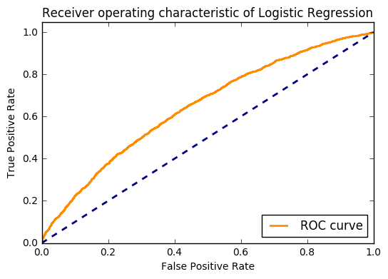

```python
# Draw the ROC curve in Logistic Regression
from sklearn.metrics import roc_curve

score = lr.decision_function(testX)
fpr, tpr, thresholds = roc_curve(testY, score)

print 'fpr = ', fpr
print 'tpr = ', tpr

plt.figure()
lw = 2
plt.plot(fpr, tpr, color='darkorange',
         lw=lw, label='ROC curve')
plt.plot([0, 1], [0, 1], color='navy', lw=lw, linestyle='--')
plt.xlim([0.0, 1.0])
plt.ylim([0.0, 1.05])
plt.xlabel('False Positive Rate')
plt.ylabel('True Positive Rate')
plt.title('Receiver operating characteristic of Logistic Regression')
plt.legend(loc="lower right")
plt.show()
```

## 0X00100 Problem 4

```python
# Calculate the precision and recall in k-Nearest Neighbors
from sklearn.metrics import precision_score
from sklearn.metrics import recall_score

y_pred = neigh.predict(testX)
y_true = testY

print "Precision of k-Nearest Neighbors: %1.3f" % precision_score(y_true, y_pred)
print "Recall of k-Nearest Neighbors:    %1.3f" % recall_score(y_true, y_pred)
```

```
Precision of k-Nearest Neighbors: 0.452
Recall of k-Nearest Neighbors:    0.080
```

## 0X00101 Problem 5

```
Confusion matrix of Naive Bayes Classifier:
[[1518 5485]
 [ 197 1800]]
```

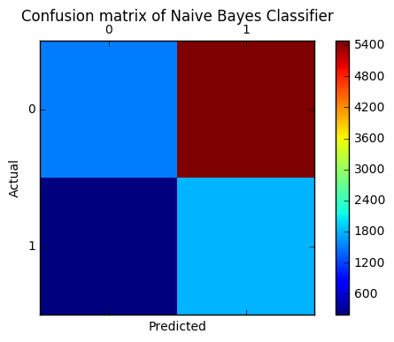

```python
# Draw the Confusion Matrix of Naive Bayes
from sklearn.metrics import confusion_matrix
import itertools

y_pred = gnb.predict(testX)
y_true = testY
cm = confusion_matrix(y_true, y_pred)

labels = [0, 1]
cm = confusion_matrix(y_true, y_pred, labels)


print 'Confusion matrix of Naive Bayes Classifier:\n', cm
fig = plt.figure()
ax = fig.add_subplot(1,1,1)
cax = ax.matshow(cm)
plt.title('Confusion matrix of Naive Bayes Classifier')
fig.colorbar(cax)
ax.set_xticklabels([''] + labels)
ax.set_yticklabels([''] + labels)
plt.xlabel('Predicted')
plt.ylabel('Actual')
plt.show()
```

## 0X00110 Problem 6

```python
# What is the performance with different parameters in SVM

from sklearn.svm import SVC
c = 1.0
li = []
while c < 10.0:
    c = c + 1.0
    svmC = SVC(C=c).fit(trainX, trainY)
    SVMAC = svmC.score(testX,testY)
    print 'Accuracy of SVM model (C = %.1f) :  %f' %(c,SVMAC)
    li.append(SVMAC)
```

```
Accuracy of SVM model (C = 2.0) :  0.777000
Accuracy of SVM model (C = 3.0) :  0.777556
Accuracy of SVM model (C = 4.0) :  0.777000
Accuracy of SVM model (C = 5.0) :  0.777111
Accuracy of SVM model (C = 6.0) :  0.776889
Accuracy of SVM model (C = 7.0) :  0.776667
Accuracy of SVM model (C = 8.0) :  0.776667
Accuracy of SVM model (C = 9.0) :  0.776778
Accuracy of SVM model (C = 10.0) :  0.776778
```

```python
g = 1.0
lig = []
while g < 20:
    ga = 1.0/g
    svmC = SVC(C=5.0,gamma=ga).fit(trainX, trainY)
    SVMAC = svmC.score(testX,testY)
    print 'Accuracy of SVM model (gamma = %.4f) :  %f' %(ga,SVMAC)
    lig.append(SVMAC)
    g = g + 2.0
```

```
Accuracy of SVM model (gamma = 1.0000) :  0.777667
Accuracy of SVM model (gamma = 0.3333) :  0.776778
Accuracy of SVM model (gamma = 0.2000) :  0.777000
Accuracy of SVM model (gamma = 0.1429) :  0.777111
Accuracy of SVM model (gamma = 0.1111) :  0.777444
Accuracy of SVM model (gamma = 0.0909) :  0.776889
Accuracy of SVM model (gamma = 0.0769) :  0.776556
Accuracy of SVM model (gamma = 0.0667) :  0.776667
Accuracy of SVM model (gamma = 0.0588) :  0.776556
Accuracy of SVM model (gamma = 0.0526) :  0.777000
```

I tried to change the values of parameters C and gamma，but the results of test data are very similar

## 0X00111 Problem 7

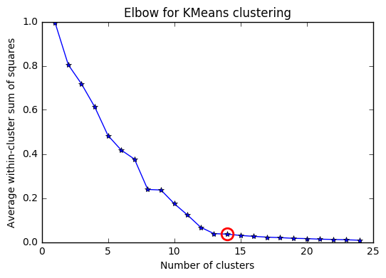

```python
# Problem 7
# According to Gender, Education, and Marital status, how many kinds of customer should be divided into?
from sklearn.cluster import KMeans
from scipy.spatial.distance import cdist, pdist

CX = trainData[:,1:4].astype(float)

K = range(1,25)
KM = [KMeans(n_clusters=k).fit(CX) for k in K]
centroids = [k.cluster_centers_ for k in KM]
D_k = [cdist(CX, cent, 'euclidean') for cent in centroids]
cIdx = [np.argmin(D,axis=1) for D in D_k]
dist = [np.min(D,axis=1) for D in D_k]
avgWithinSS = [sum(d)/CX.shape[0] for d in dist]

wcss = [sum(d**2) for d in dist]
tss = sum(pdist(CX)**2)/CX.shape[0]
bss = tss-wcss

kIdx = 13

# elbow curve
fig = plt.figure()
plt.xlabel('Number of clusters')
plt.ylabel('Average within-cluster sum of squares')
plt.title('Elbow for KMeans clustering')
ax = fig.add_subplot(111)
ax.plot(K, avgWithinSS, 'b*-')
ax.plot(K[kIdx], avgWithinSS[kIdx], marker='o', markersize=12,
markeredgewidth=2, markeredgecolor='r', markerfacecolor='None')
plt.show()
```

According to the figure, I think customers will be divided into 14 kinds

## 0X01000 Feel free and try more ^_^

### 1. Analysis of the probability of default payment (Female/male)

- we can know male's default payment percentage is a little higher than female

```python
# X2: Gender (1 = male; 2 = female).
# X3: Education (1 = graduate school; 2 = university; 3 = high school; 4 = others).
# X4: Marital status (1 = married; 2 = single; 3 = others).

femaleDefault = df[ ( df['X2'] == 2 )  & ( df['Y'] == 1 ) ]
femaleTotal = df[ df['X2'] == 2 ]

maleDefault = df[ ( df['X2'] == 1 )  & ( df['Y'] == 1 ) ]
maleTotal = df[ df['X2'] == 1 ]

print '----------------------------------------------------'

print 'Female with default payment : ', len(femaleDefault)
print 'Total number of female : ', len(femaleTotal)
print 'Percentage of default payment :', \
    float(len(femaleDefault))/len(femaleTotal)

print '----------------------------------------------------'

print 'Male with default payment : ', len(maleDefault)
print 'Total number of male : ', len(maleTotal)
print 'Percentage of default payment :', \
    float(len(maleDefault))/len(maleTotal)
```

```
----------------------------------------------------
Female with default payment :  3763
Total number of female :  18112
Percentage of default payment : 0.207762809187
----------------------------------------------------
Male with default payment :  2873
Total number of male :  11888
Percentage of default payment : 0.241672274563
```

### 2. Using Neural Networks to analyze test data

- Testing different learning rate schedules and momentum parameters

```
learning on dataset Default of credit card clients Data Set
Training: constant learning-rate
Training set score: 0.815000
Training set loss: 0.446459
Training: constant with momentum
Training set score: 0.815286
Training set loss: 0.444421
Training: constant with Nesterov's momentum
Training set score: 0.821381
Training set loss: 0.434826
Training: inv-scaling learning-rate
Training set score: 0.780810
Training set loss: 0.493923
Training: inv-scaling with momentum
Training set score: 0.807524
Training set loss: 0.459182
Training: inv-scaling with Nesterov's momentum
Training set score: 0.806381
Training set loss: 0.461438
Training: adam
Training set score: 0.814667
Training set loss: 0.439417
```

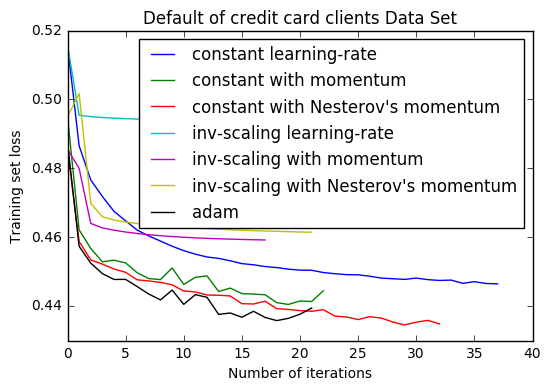

```python
from sklearn.neural_network import MLPClassifier
from sklearn.preprocessing import MinMaxScaler

# different learning rate schedules and momentum parameters
params = [{'solver': 'sgd', 'learning_rate': 'constant', 'momentum': 0,
           'learning_rate_init': 0.2},
          {'solver': 'sgd', 'learning_rate': 'constant', 'momentum': .9,
           'nesterovs_momentum': False, 'learning_rate_init': 0.2},
          {'solver': 'sgd', 'learning_rate': 'constant', 'momentum': .9,
           'nesterovs_momentum': True, 'learning_rate_init': 0.2},
          {'solver': 'sgd', 'learning_rate': 'invscaling', 'momentum': 0,
           'learning_rate_init': 0.2},
          {'solver': 'sgd', 'learning_rate': 'invscaling', 'momentum': .9,
           'nesterovs_momentum': True, 'learning_rate_init': 0.2},
          {'solver': 'sgd', 'learning_rate': 'invscaling', 'momentum': .9,
           'nesterovs_momentum': False, 'learning_rate_init': 0.2},
          {'solver': 'adam', 'learning_rate_init': 0.01}]

labels = ["constant learning-rate", "constant with momentum",
          "constant with Nesterov's momentum",
          "inv-scaling learning-rate", "inv-scaling with momentum",
          "inv-scaling with Nesterov's momentum", "adam"]

plot_args = [{'c': 'red', 'linestyle': '-'},
             {'c': 'green', 'linestyle': '-'},
             {'c': 'blue', 'linestyle': '-'},
             {'c': 'red', 'linestyle': '--'},
             {'c': 'green', 'linestyle': '--'},
             {'c': 'blue', 'linestyle': '--'},
             {'c': 'black', 'linestyle': '-'}]

trainData = np.array(train).astype(float)
testData = np.array(test).astype(float)

trainX = trainData[:,:-1]
trainY = trainData[:,-1]

def plot_on_dataset(X, y, ax, name):
    # plot learning for each learning strategy
    print("\nlearning on dataset %s" % name)
    ax.set_title(name)
    X = MinMaxScaler().fit_transform(X)
    max_iter = 50

    for label, param in zip(labels, params):
        print("Training: %s" % label)
        mlp = MLPClassifier(verbose=0, random_state=0,max_iter=max_iter, **param)
        mlp.fit(X, y)
        print("Training set score: %f" % mlp.score(X, y))
        print("Training set loss: %f" % mlp.loss_)
        ax.plot(mlp.loss_curve_, label=label)

ax= plt.subplot(111)
plot_on_dataset(trainX, trainY, ax=ax, name='Default of credit card clients Data Set')
plt.legend(ax.get_lines(), labels=labels, loc="upper right")
plt.xlabel('Number of iterations')
plt.ylabel('Training set loss')
plt.show()
```